# Assignment 9: Spatial Analysis in R

Janice Ye

## OVERVIEW

This exercise accompanies the lessons in Environmental Data Analytics (ENV872L) on spatial analysis.

## Directions

1. Rename this file `<FirstLast>_A09_SpatialAnalysis.Rmd` (replacing `<FirstLast>` with your first and last name).
2. Change “Student Name” on line 3 (above) with your name.
3. Use the lesson as a guide. It contains code that can be modified to complete the assignment.
4. Work through the steps, **creating code and output** that fulfill each instruction.
5. Be sure to **answer the questions** in this assignment document. Space for your answers is provided in this document and is indicated by the “>” character. If you need a second paragraph be sure to start the first line with “>”. You should notice that the answer is highlighted in green by RStudio.
6. When you have completed the assignment, **Knit** the text and code into a single HTML file.

## DATA WRANGLING

### Set up your session

1. Import libraries: tidyverse, sf, leaflet, here, and mapview
2. Execute the `here()` command to display the current project directory

```r
#1.
library(tidyverse)
library(sf)
library(leaflet)
library(here)
```

```r
library(mapview)
#2.
here()
```

```
## [1] "/home/guest/EDA_Spring2024"
```

### Read (and filter) county features into an sf dataframe and plot

In this exercise, we will be exploring stream gage height data in Nebraska corresponding to floods occurring there in 2019. First, we will import from the US Counties shapefile we’ve used in lab lessons, filtering it this time for just Nebraska counties. Nebraska’s state FIPS code is `31` (as North Carolina’s was `37`).

3. Read the `cb_2018_us_county_20m.shp` shapefile into an sf dataframe, filtering records for Nebraska counties (State FIPS = 31)
4. Reveal the dataset’s coordinate reference system
5. Plot the records as a map (using `mapview` or `ggplot`)

```r
#3. Read in Counties shapefile into an sf dataframe, filtering for just NE counties
nebraska.data.sf <- st_read(here('Data/Spatial/cb_2018_us_county_20m.shp')) %>%
  filter(STATEFP == 31)
#4. Reveal the CRS of the counties features
st_crs(nebraska.data.sf)
```

```
## Coordinate Reference System:
##   User input: NAD83
##   wkt:
## GEOGCRS["NAD83",
##     DATUM["North American Datum 1983",
##         ELLIPSOID["GRS 1980",6378137,298.257222101,
##             LENGTHUNIT["metre",1]]],
##     PRIMEM["Greenwich",0,
##         ANGLEUNIT["degree",0.0174532925199433]],
##     CS[ellipsoidal,2],
##         AXIS["latitude",north,
##             ORDER[1],
##             ANGLEUNIT["degree",0.0174532925199433]],
##         AXIS["longitude",east,
##             ORDER[2],
##             ANGLEUNIT["degree",0.0174532925199433]],
##     ID["EPSG",4269]]
```

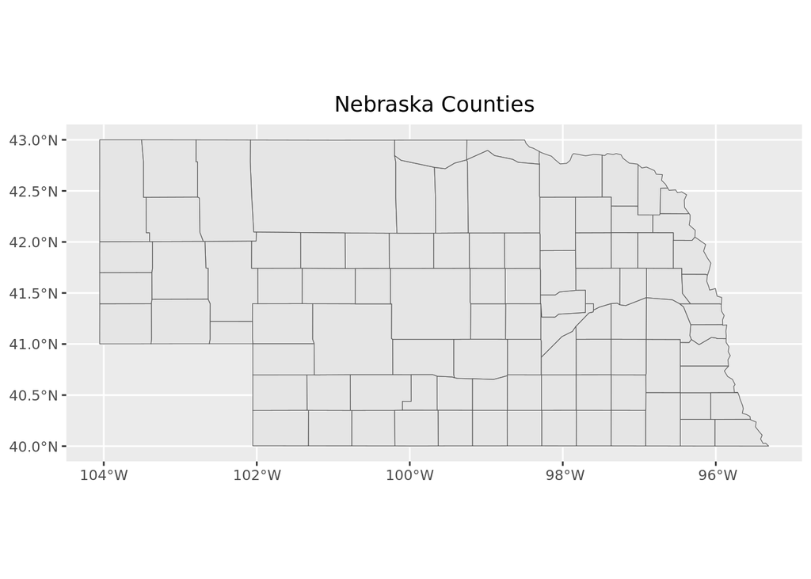

```r
#5. Plot the data
nebraska.plot <- ggplot(nebraska.data.sf) +
  geom_sf() +
  ggtitle("Nebraska Counties") +
  theme(plot.title = element_text(hjust = 0.5))
print(nebraska.plot)
```

6. What is the EPSG code of the Counties dataset? Is this a geographic or a projected coordinate reference system? (Or, does this CRS use angular or planar coordinate units?) To what datum is this CRS associated? (Tip: look for the EPSG code on https://spatialreference.org and examine the link for “Well Known Text as HTML” or “Human-Readable OGC WKT”…)

> ANSWER: The EPSG code is 4269. This is a geographic coordinate reference system. It uses angular corrdinate unit in degree. This CRS is associated with datum NAD 83, which uses GRS 1980 ellipsoid.

### Read in gage locations csv as a dataframe, then display the column names it contains

Next we’ll read in some USGS/NWIS gage location data added to the `Data/Raw` folder. These are in the `NWIS_SiteInfo_NE_RAW.csv` file.(See `NWIS_SiteInfo_NE_RAW.README.txt` for more info on this dataset.)

7. Read the NWIS_SiteInfo_NE_RAW.csv file into a standard dataframe, being sure to set the `site_no` field as well as other character columns as a factor.
8. Display the column names of this dataset.

```r
#7. Read in gage locations csv as a dataframe
gage.location <- read.csv(here("Data/Raw/NWIS_SiteInfo_NE_RAW.csv"),
                          colClasses = c('site_no' = 'factor',
                                         'station_nm' = 'factor',
                                         'site_tp_cd' = 'factor',
                                         'coord_acy_cd' = 'factor',
                                         'dec_coord_datum_cd' = 'factor'))

#8. Reveal the names of the columns
colnames(gage.location)
```

```
## [1] "site_no"            "station_nm"         "site_tp_cd"
## [4] "dec_lat_va"         "dec_long_va"        "coord_acy_cd"
## [7] "dec_coord_datum_cd"
```

9. What columns in the dataset contain the x and y coordinate values, respectively?  
   > ANSWER: In the dataset, “dec_long_va” is the x coordinate values and “dec_lat_va” is the y coordinate values.

### Convert the dataframe to a spatial features (“sf”) dataframe

10. Convert the dataframe to an sf dataframe.
- Note: These data use the same coordinate reference system as the counties dataset
11. Display the column names of the resulting sf dataframe

```r
#10. Convert to an sf object
gage.location.sf <- gage.location %>%
  st_as_sf(coords = c('dec_long_va',  'dec_lat_va'), crs = 4269)

#11. Re-examine the column names
colnames(gage.location.sf)
```

```
## [1] "site_no"            "station_nm"         "site_tp_cd"
## [4] "coord_acy_cd"       "dec_coord_datum_cd" "geometry"
```

12. What new field(s) appear in the sf dataframe created? What field(s), if any, disappeared?

> ANSWER: “geometry” is the new field that appeared. “dec_lat_va” and “dec_long_va” disappeared.

### Plot the gage locations on top of the counties

13. Use `ggplot` to plot the county and gage location datasets.
- Be sure the datasets are displayed in different colors
- Title your plot “NWIS Gage Locations in Nebraska”
- Subtitle your plot with your name

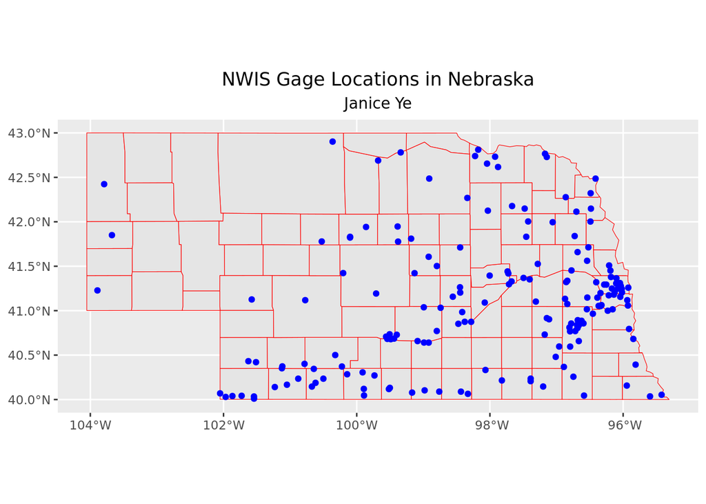

```r
#13. Plot the gage locations atop the county features
nebraska.gage.plot <- ggplot() +
  geom_sf(data = nebraska.data.sf, layer.name = "county", color = "red") +
  geom_sf(data = gage.location.sf, layer.name = "gage location", color = "blue") +
  ggtitle("NWIS Gage Locations in Nebraska", subtitle = "Janice Ye") +
  theme(plot.title = element_text(hjust = 0.5)) +
  theme(plot.subtitle = element_text(hjust = 0.5))
print(nebraska.gage.plot)
```

### Read in the gage height data and join the site location data to it.

Lastly, we want to attach some gage height data to our site locations. I’ve constructed a csv file listing many of the Nebraska gage sites, by station name and site number along with stream gage heights (in meters) recorded during the recent flood event. This file is titled `NWIS_SiteFlowData_NE_RAW.csv` and is found in the Data/Raw folder.

14. Read the `NWIS_SiteFlowData_NE_RAW.csv` dataset in as a dataframe
- Pay attention to which fields should be imported as factors!
15. Show the column names .
16. Join our site information (already imported above) to these gage height data
- The `site_no` and `station_nm` can both/either serve as joining attributes
- Construct this join so that the result only includes spatial features where both tables have data
17. Show the column names in this resulting spatial features object
18. Show the dimensions of the resulting joined dataframe

```r
#14. Read the site flow data into a data frame
gage.height <- read.csv(here("Data/Raw/NWIS_SiteFlowData_NE_RAW.csv"),
                        colClasses = c('station_nm' = 'factor',
                                       'site_no' = 'factor'))

gage.height$date <- as.Date(gage.height$date, format = "%Y-%m-%d")

#15. Show the column names
colnames(gage.height)
```

```
## [1] "site_no"    "station_nm" "date"       "gage_ht"
```

```r
#16. Join the flow data to our NWIS gage location spatial dataframe
gage.join.sf <- merge(gage.location.sf, gage.height, by = c("site_no", "station_nm"))

#17. Show the column names of the joined dataset
colnames(gage.join.sf)
```

```
## [1] "site_no"            "station_nm"         "site_tp_cd"
## [4] "coord_acy_cd"       "dec_coord_datum_cd" "date"
## [7] "gage_ht"            "geometry"
```

```r
#18. Show the dimensions of this joined dataset
dim(gage.join.sf)
```

```
## [1] 136   8
```

### Map the pattern of gage height data

Now we can examine where the flooding appears most acute by visualizing gage heights spatially. 19. Plot the gage sites on top of counties (using `mapview`, `ggplot`, or `leaflet`) * Show the magnitude of gage height by color, shape, other visualization technique.

```r
#Map the points, sized by gage height
gage.height.map <- mapview(gage.join.sf,
        zcol = "gage_ht",
        alpha.regions = 0.5) +
  mapview(nebraska.data.sf, layer.name = "county", col.regions = NA)
print(gage.height.map)
```

[output not shown]

## SPATIAL ANALYSIS

Up next we will do some spatial analysis with our data. To prepare for this, we should transform our data into a projected coordinate system. We’ll choose UTM Zone 14N (EPGS = 32614).

### Transform the counties and gage site datasets to UTM Zone 14N

20. Transform the counties and gage sf datasets to UTM Zone 14N (EPGS = 32614).
21. Using `mapview` or `ggplot`, plot the data so that each layer is shown with a unique color (e.g. counties blue and gages red)

```r
#20 Transform the counties and gage location datasets to UTM Zone 14
county.utm14.sf <- st_transform(nebraska.data.sf, crs = 32614)
gage.join.utm14.sf <- st_transform(gage.join.sf, crs = 32614)

#21 Plot the data
mapview(county.utm14.sf, layer.name = "county", col.regions = NA) +
  mapview(gage.join.utm14.sf, layer.name = "gage", col.regions = "red")
```

[interactive chart not shown]

### Select the gages falling within a given county

Now let’s zoom into a particular county and examine the gages located there. 22. Select Lancaster county from your projected county sf dataframe 23. Select the gage sites falling `within` that county * Use either matrix subsetting or tidy filtering 24. Create a plot showing: * all Nebraska counties, * the selected county, * and the gage sites in that county

```r
#22 Select the county
lancaster.utm14.sf <- filter(county.utm14.sf, NAME == "Lancaster")

#23 Spatially select gages within the selected county
gage.lancaster <- gage.join.utm14.sf[lancaster.utm14.sf,]

#24 Plot
mapview(county.utm14.sf, col.regions = NA) +
  mapview(lancaster.utm14.sf) +
  mapview(gage.lancaster, col.regions = "red")
```

[interactive chart not shown]